# Platypus vignette

### 6.8 Neighbor-joining phylogenetic trees

The output of the VDJ_clonal_lineage function can be used as input to the VDJ_tree to produce quick, neighbor-joining phylogenetic trees. It is important that the VDJRegion is considered (or that the sequences from 10x have been trimmed) as this function does not involve a multiple string alignment - instead it creates a distance matrix from all sequences. The min number of unique sequences can be specified (e.g., if there are 50 cells in a clonal lineage, but only one unique antibody sequence, this tree will not be produced). Similarly, the max number of sequences can be specified, which will then result in random sampling from all sequences. Plotting the first tree we can see the that there is one variant (named Seq_1) that has 90 cells (seen by the Freq_90) and it is very close to the germline (Seq_6_Freq_1). We know it is the germline because it is the highest sequence variant and it is set as the root.

```r
covid_trees <- Platypus::VDJ_tree(clonal.lineages = covid_clonal_lineages,with.germline=T,min.sequences = 5,max.sequences = 30,unique.sequences = T)
```

```
## [1] 1
## [1] 2
```

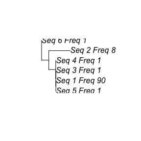

```r
plot(covid_trees[[1]][[1]])
```

### 6.9 Plotting per-cell isotype information

Additional VDJ functions include plotting the isotype distribution per clone. This can be performed by the VDJ_isotypes_per_clone function and setting the number of clones to show. The following code extracts and plots the isotype distribution of the top 30 clones. We can see a clear IgA isotype majority of the top four clones in the first patient when using the default clonotyping strategy. We can additionally use the new clonotyping strategies to compare how changing the clonal defintion impacts the clonal expansion profiles. We simply supply the output from VDJ_clonotype

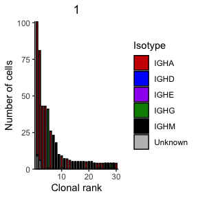

```r
covid_isotypes <- Platypus::VDJ_isotypes_per_clone(VDJ_clonotype_output = covid_vdj_repertoire_bcells, VDJ_per_clone_output = covid_single_cell, clones = 30)

covid_isotypes_aa_clonotype <- Platypus::VDJ_isotypes_per_clone(VDJ_clonotype_output = covid_vdj_germline_clonotype, VDJ_per_clone_output = covid_single_cell, clones = 30)

covid_isotypes_germline_clonotype <- Platypus::VDJ_isotypes_per_clone(VDJ_clonotype_output = covid_vdj_aminoacid_clonotype, VDJ_per_clone_output = covid_single_cell, clones = 30)

print(covid_isotypes[[1]])
```

In the second patient (second repertoire entered in original VDJ_analyze) we also see a similarly expanded IgA clone with over 60 cell barcodes.

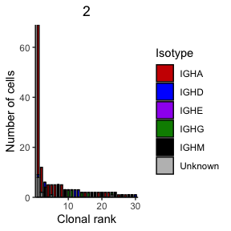

```r
print(covid_isotypes[[2]])
```

### 6.10 Sequence similarity networks

Other functions are specifically tailored to repertoire analysis - such as VDJ_network, which creates a sequence similarity network between repertoires or within a repertoire by connecting those clones with sequence similarity. This function relies upon igraph to visually display and construct the graph - which means that networks with high number of sequences will not display easily. In the following example we take the top 60 most expanded clones from the output of VDJ_analyze and use this as input into the network construction function. Setting the per.mouse argument to false indicates that one network for multiple repertoires should be produced.

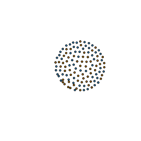

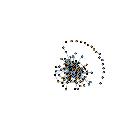

```r
## Take the output from VDJ_analyze (or subsample as in this case the top 60 clones)
network_clones_covid <- list()
network_clones_covid[[1]] <- covid_vdj_repertoire_bcells[[1]][1:60,]
network_clones_covid[[2]] <- covid_vdj_repertoire_bcells[[2]][1:60,]
network_clones_covid <- list()
network_clones_covid[[1]] <- covid_vdj_repertoire_tcells[[1]][1:60,]
network_clones_covid[[2]] <- covid_vdj_repertoire_tcells[[2]][1:60,]

covid_bcell_igraph <- Platypus::VDJ_network(network_clones_covid[1:2],per.sample = F,distance.cutoff = 10,connected = F)
covid_bcell_igraph_d14 <- Platypus::VDJ_network(network_clones_covid[1:2],per.sample = F,distance.cutoff = 14,connected = F)


igraph::plot.igraph(covid_bcell_igraph[[4]],vertex.label=NA,vertex.size=7+(.06*covid_bcell_igraph[[2]]$frequency),vertex.color=factor(covid_bcell_igraph[[2]]$mouse))
igraph::plot.igraph(covid_bcell_igraph_d14[[4]],vertex.label=NA,vertex.size=7+(.06*covid_bcell_igraph_d14[[2]]$frequency),vertex.color=factor(covid_bcell_igraph_d14[[2]]$mouse))
```

### 6.11 Germline gene usage heatmaps

It is also possible to produce heatmaps of the germline gene usage in the context of heavy chain V gene and light chain V gene. The output of the VDJ_Vgene_usage function is a matrix for each repertoire corresponding to the order specified by VDJ_analyze. The outer list corresponds to the sample and the inner list corresponds to a matrix, where the rows correspond to the heavy chain V genes and the columns correspond to the light chains of the V genes. Therefore the output[[1]][i,j] corresponds to the number of clones using the combination of IGH-Vgene[i] and IGK/L-Vgene[j].

```r
#First calculate adjacency matrix for V gene usage
covid_Vgene_usage <- Platypus::VDJ_Vgene_usage(VDJ.clonotype.output = covid_vdj_repertoire_bcells)
library(pheatmap)

pheatmap::pheatmap(covid_Vgene_usage[[1]],show_rownames = F,show_colnames = F)


print(class(covid_Vgene_usage[[1]]))
```

```
## [1] "matrix" "array"
```

```r
print(head(rownames(covid_Vgene_usage[[1]])))
```

```
## [1] "IGHV3-11" "IGHV4-39" "IGHV1-69" "IGHV4-61" "IGHV4-34" "IGHV3-23"
```

```r
print(head(colnames(covid_Vgene_usage[[1]])))
```

```
## [1] "IGKV1-33" "IGKV1-6"  "IGKV3-11" "IGLV2-14" "IGKV1-5"  "IGLV1-44"
```

[figure not shown]

This can then be easily plotted as a heatmap to observe patterns between repertoires or can be used to calculate V gene correlation using the “pheatmap” package.

Platypus also allows a separate analysis of V gene usage for HC and LC. The VDJ_Vgene_usage_barplot allows the user to plot most frequently used IgH or IgK/L V genes. By default, this function only provides visualizations for the HC V genes, but can also provide for the LC if LC. Vgene is set to TRUE. The User can also select the number of most used genes to be depicted.

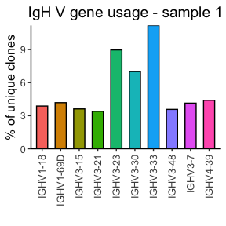

```r
covid_Vgene_usage_barplot <- Platypus::VDJ_Vgene_usage_barplot(covid_vdj_repertoire_bcells, HC.gene.number = 10, LC.Vgene = T, LC.gene.number = 10)
print(covid_Vgene_usage_barplot[[1]])
```

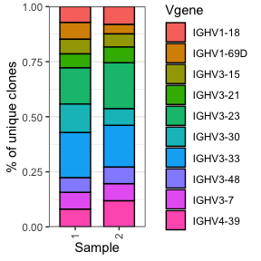

```r
example.vdj.vgene_usage <- Platypus::VDJ_Vgene_usage_stacked_barplot(clonotype.list = covid_vdj_repertoire_bcells, LC.Vgene = F,HC.gene.number = 10, Fraction.HC = 1)
example.vdj.vgene_usage[[1]]
```

Furthermore, we can also produce a circular visualization of how V and J genes are combined throughout the repertoire. In the example that follows we use VDJ_VJ_usage_circos to look at the V gene with the corresponding J gene for each expanded clonotype.

```r
vj_circos_bcells <- Platypus::VDJ_VJ_usage_circos(covid_vdj_repertoire_bcells[2:2], c.threshold = 1,label.threshold=50,cell.level = T)
```

```
## [1] "Reminder: VDJ_VJ_usage_circos() funcion built for Platypus 2.0.5 is being used. Output of VDJ_analyze() required as input. Set [platypus.version = new] for compatibility with VDJ_GEX_matrix()."
```

[output not shown]

[figure not shown]

```r
vj_circos_tcells <- Platypus::VDJ_VJ_usage_circos(covid_vdj_repertoire_tcells[1:1], c.threshold = 1,label.threshold=50,cell.level = T)
```

```
## [1] "Reminder: VDJ_VJ_usage_circos() funcion built for Platypus 2.0.5 is being used. Output of VDJ_analyze() required as input. Set [platypus.version = new] for compatibility with VDJ_GEX_matrix()."
```

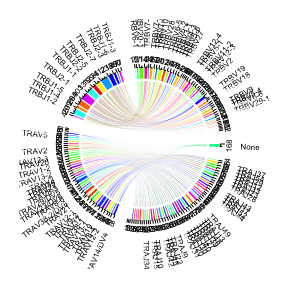

### 6.12 Assessing CDR3 sequence similarity

Finally, one can also look at any specific HC and LC CDR3 amino acid patterns arising across the different clones. Using the VDJ_logoplot function the user can plot a logoplot of the CDR3 region od a certain length, specyfied by the length_cdr3 argument. For instance, the logoplot below corresponds to all those CDR3 aminoacid sequences of length 25

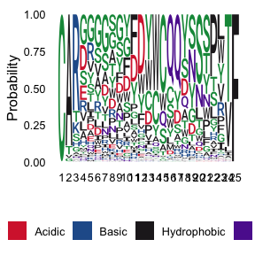

```r
covid_CDR3_logoplot <- Platypus::VDJ_logoplot(VDJ.object = covid_vdj_repertoire_bcells, length_cdr3 = 25)
```

## 7. Integrating repertoire and gene expression

The strength of the current 5’ sequencing protocols are that the gene expression (GEX) and repertoire (VDJ) libraries are extracted from the same sample, which can then be linked back to demonstrate that a given T cell has a certain gene expression pattern and also a certain T cell receptor sequence. The following functions are meant to integrate these two pieces of information.

### 7.1 Integrating transcriptional clusters to the VDJ objects

One thing we may ask is how similar the B or T cells in a given clonal family are on the transcriptional level. One way we can do this, is to take advantage of the transcriptional clustering performed in the automate_GEX function and then supply this information to the repertoire information. This can either be done on the level of the clone (e.g., in the format of the output of VDJ_analyze) or on the level of the cell (e.g., in the format of the output of VDJ_per_clone). Below is the example of the clonal level. The output is the same as the VDJ_analyze output, except now there are columns corresponding to the majority transcriptome cluster (e.g., if the majority of cells within the clone are in cluster 1, then this column will have a 1). Next to this there is a column that tells you the cluster percentage for all cells in that clone. Finally, there is the cell index in the GEX object so you can see which cells are found in the GEX object and can explicitly call them.

```r
covid_integrating_clonal_level <- Platypus::VDJ_GEX_integrate(GEX.object = covid_gex[[1]],
                                                 clonotype.list =  covid_vdj_repertoire_bcells,
                                                 VDJ.per.clone = covid_single_cell,
                                                 clonotype.level = TRUE)
covid_integrating_clonal_level_tcell <- Platypus::VDJ_GEX_integrate(GEX.object = covid_gex[[1]],
                                                 clonotype.list =  covid_vdj_repertoire_tcells,
                                                 VDJ.per.clone = covid_single_cell,
                                                 clonotype.level = TRUE)

print(head(covid_integrating_clonal_level[[1]]$majority_cluster))
```

```
## [1] "1" "1" "1" "4" "7" "7"
```

```r
print(head(covid_integrating_clonal_level[[1]]$cluster_membership_percent))
```

```
## [1] "17.6470588235294, 23.5294117647059, 0, 0, 17.6470588235294, 17.6470588235294, 17.6470588235294, 0, 5.88235294117647, 0, 0, 0, 0"
## [2] "23.0769230769231, 30.7692307692308, 0, 0, 15.3846153846154, 23.0769230769231, 7.69230769230769, 0, 0, 0, 0, 0, 0"
## [3] "0, 37.5, 0, 0, 37.5, 12.5, 12.5, 0, 0, 0, 0, 0, 0"
## [4] "22.2222222222222, 11.1111111111111, 0, 0, 33.3333333333333, 22.2222222222222, 11.1111111111111, 0, 0, 0, 0, 0, 0"
## [5] "0, 0, 0, 2.7027027027027, 2.7027027027027, 0, 0, 94.5945945945946, 0, 0, 0, 0, 0"
## [6] "0, 0, 0, 0, 0, 0, 0, 100, 0, 0, 0, 0, 0"
```

```r
print(head(covid_integrating_clonal_level[[1]]$cell_index))
```

```
## [1] "103;228;517;906;1428;1615;1636;1725;2513;2717;2833;3570;5528;6137;6787;12867;12890"
## [2] "693;1679;2245;2761;3763;10328;4699;5051;5580;6318;6519;6786;6820"
## [3] "1353;2940;3475;3699;3861;4194;4814;6111"
## [4] "273;626;651;2333;3726;4848;5476;5798;6705"
## [5] "300;469;684;949;1069;1142;1343;1618;1939;2044;2301;2448;2578;3079;3168;3209;3258;3389;3684;3710;4129;4159;4227;4385;4400;4466;4520;4526;4633;4726;4817;11423;5372;5643;5723;5781;5813"
## [6] "388;473;1095;1229;1276;2413;2419;2454;2665;3345;3608;3922;3961;4296;4476;5148;5215;5306;5409;5943;6029;6581;6630;6718"
```

```r
covid_integrating_cell_level <- Platypus::VDJ_GEX_integrate(GEX.object = covid_gex[[1]],
                                                 clonotype.list =  covid_vdj_repertoire_bcells[1:1],
                                                 VDJ.per.clone = covid_single_cell[1:1],
                                                 clonotype.level = FALSE)


print(head(covid_integrating_cell_level[[1]][[5]]$cluster_membership))
```

```
## [1] "" "" "" "" "" ""
```

```r
print(head(covid_integrating_cell_level[[1]][[5]]$cell_index))
```

```
## [1] "" "" "" "" "" ""
```

### 7.2 Relating clonal expansion to transcriptional cluster membership

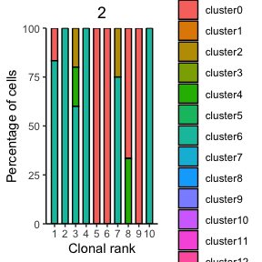

```r
covid_clonotype_clusters_plot <-  Platypus::VDJ_GEX_expansion(GEX.list=covid_gex[[1]],
                                                              VDJ.GEX.integrate.list = covid_integrating_clonal_level,
                                                              highlight.isotype = "None",
                                                              highlight.number=1:10)
covid_clonotype_clusters_plot_tcells <-  Platypus::VDJ_GEX_expansion(GEX.list=covid_gex[[1]],
                                                              VDJ.GEX.integrate.list = covid_integrating_clonal_level_tcell,
                                                              highlight.isotype = "None",
                                                              highlight.number=1:10)

print(covid_clonotype_clusters_plot_tcells[[2]])
```

### 7.3 Visualizing clones on the 2 dimensional landscape

In the case we want to overlay clones on the tSNE/UMAP space that we previously calculated using automate_GEX, this can be accomplished with the visualize_clones_GEX function. The following code will overlay the top 10 clones on the UMAP space calculated with the automate_GEX function. The group correspond to the clonal order - e.g., group 1 is the first clonal family in the integrated VDJ list. Here we can see that there are a few cells in the T cell cluster, suggesting that there were duplets during cell capture since in this experiment B and T cells were pooled in a single reaction.

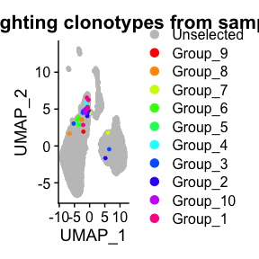

```r
covid_top10_umap <- Platypus::GEX_visualize_clones(GEX.list=covid_gex,
                     VDJ.GEX.integrate.list=covid_integrating_clonal_level_tcell[2:2],
                     highlight.type="clonotype",
                     highlight.number=1:10,
                     reduction="umap")
print(covid_top10_umap[[1]])
```

### 7.4 Specific gene expression information on the clonal level

We previously integrated the GEX information into the format of the VDJ output. However, we may want to ask how the gene expression looks for certain clonotypes (e.g., how many of the cells in the top clone are expressing Fas/GL7 or germinal center cell markers). Therefore, we need to integrate the VDJ information and barcodes into the GEX object. This can be done by using the clonotype_GEX function followed by the GEX_heatmap function. To save space, the output of this function can be assigned to the original automate_GEX output, as it will be another Seurat object. By setting b.or.t to “b”, a panel of pre-selected B cell genes will be displayed. One can also supply custom genes to test specific clonotypes. The group/column colors correspond to given clonal families.

```r
covid_gex_integrate <- Platypus::GEX_clonotype(GEX.object=covid_gex[[1]],VDJ.per.clone = covid_single_clone_tcells)
```

```
## [1] "1 from 2 repertoires"
## ================================================================================[1] "2 from 2 repertoires"
## ================================================================================
```

```r
covid_gex_integrate_bcells <- Platypus::GEX_clonotype(GEX.object=covid_gex[[1]],VDJ.per.clone = covid_single_cell)
```

```
## [1] "1 from 2 repertoires"
## ================================================================================[1] "2 from 2 repertoires"
## ================================================================================
```

```r
GEX_phenotype_per_clone_plot <- Platypus::GEX_phenotype_per_clone(seurat.object = covid_gex_integrate, clonotype.ids= c(1,2,3,4,5))
```

```
## [1] "data.frame"
##            Unclassified MemoryCD8 EffectorCD8 clonotype_id
## clonotype1    0.8181818         0   0.1818182   clonotype1
## clonotype2    0.8333333         0   0.1666667   clonotype2
## clonotype3    1.0000000         0   0.0000000   clonotype3
## clonotype4    1.0000000         0   0.0000000   clonotype4
## clonotype5    0.8333333         0   0.1666667   clonotype5
##    clonotype_id     variable     value
## 1    clonotype1 Unclassified 0.8181818
## 2    clonotype2 Unclassified 0.8333333
## 3    clonotype3 Unclassified 1.0000000
## 4    clonotype4 Unclassified 1.0000000
## 5    clonotype5 Unclassified 0.8333333
## 6    clonotype1    MemoryCD8 0.0000000
## 7    clonotype2    MemoryCD8 0.0000000
## 8    clonotype3    MemoryCD8 0.0000000
## 9    clonotype4    MemoryCD8 0.0000000
## 10   clonotype5    MemoryCD8 0.0000000
## 11   clonotype1  EffectorCD8 0.1818182
## 12   clonotype2  EffectorCD8 0.1666667
## 13   clonotype3  EffectorCD8 0.0000000
## 14   clonotype4  EffectorCD8 0.0000000
## 15   clonotype5  EffectorCD8 0.1666667
```

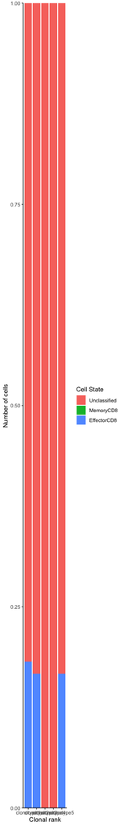

```r
print(GEX_phenotype_per_clone_plot)
```

```r
covid_tcell_gene_heatmap <- Platypus::GEX_heatmap(covid_gex_integrate,b.or.t = "t",clone.rank.threshold = 20,sample.index = 1)


covid_bcell_gene_heatmap <- Platypus::GEX_heatmap(covid_gex_integrate_bcells,b.or.t = "b",clone.rank.threshold = 20,sample.index = 1)
```

[output not shown]

### 7.5 Integrating clonal lineage information and transcriptional cluster information

```r
clonal_lineage_integrate <- Platypus::VDJ_GEX_clonal_lineage_clusters(covid_integrating_cell_level,covid_clonal_lineages[1:1])

print(clonal_lineage_integrate[[1]][[1]]$Name[1])
```

```
## [1] "clonotype3_1_IGHA1_AACCATGAGTGGAGTC-1_cluster"
```